# Stochastic mortality modelling using StMoMo

University of Toronto, STA2535

Prof. S. Pesenti

20/09/2021

# The Lee-Carter model

We assume that the number of deaths of people aged $x$ at time $t$, that die within calendar year $t$, $D(t,x)$, are modelled by a Poisson random variable
$$D(t, x) \sim Pois\left(E(t,x)\, \mu(t, x)\right)\,,$$
where $E(t,x)$ is the average population during calendar year $t$ of people aged $x$, and $\mu(t,x)$ the force of mortality of people aged $x$ at time $t$.

Moreover, the force of mortality $\mu(t,x)$ is modelled through

$$\log\left( \, \mu(t,x)\,\right)
=
\alpha_x + \beta_x \kappa_t + \epsilon_{x,t}$$
with constraints
$$\sum_t \kappa_t = 0
\quad \text{and}\quad
\sum_x \beta_x = 1\,.$$
**Identifiability issue**

The above constraints are necessary since the following reparametrisation yields exactly the same model. For $c_1$ and $c_2 \neq 0$, we can rewrite the dynamics for $\mu(t,x)$ using
$$(\alpha_x,\; \beta_x,\; \kappa_t)
\rightarrow
\left(\alpha_x + c_1 \beta_x,\; \frac{1}{c_2}\beta_x, \;c_2(\kappa_t - c_1) \right) \,.$$
Indeed, using this reparametrisation, we obtain
$$\begin{align}
\log\left( \, \mu(t,x)\,\right)
= \alpha_x + c_1 \beta_x + \frac{1}{c_2}\beta_x\, c_2(\kappa_t - c_1)+ \epsilon_{x,t}
= \alpha_x + \beta_x \kappa_t + \epsilon_{x,t}\,.
\end{align}$$

Thus, without the constraints it would be impossible to estimate the parameters.

## Initialising the Lee-Carter model

First we need to install the **StMoMo** package:

```r
require(StMoMo)
```

Next, we need to implement the function that implements the constraint, that is the transformation that yields the same dynamics for $\mu(t,x)$.

```r
constLC <- function(ax, bx, kt, b0x, gc, wxt, ages) {
    # sum over the reparametrised kt
    c1 <- mean(kt[1, ], na.rm = TRUE)
    # sum over the reparametrised bx
    c2 <- sum(bx[, 1], na.rm = TRUE)
    # reparametrisation
    list(ax = ax + c1 * bx, bx = bx/c2, kt = c2 * (kt - c1))
}
```

How to find `c1` and `c2`? The constraints have to be fulfilled for the reparametrised parameters. Denote $\tilde{\alpha}_x:= \alpha_x + c_1 \beta_x$, $\tilde{\beta}_x := \frac{1}{c_2}\beta_x$, and $\tilde{\kappa}_t := c_2(\kappa_t - c_1)$. Then, the constrains become

$$\sum_t \tilde{\kappa}_t
= c_2 \left(\sum_t (\kappa_t - c_1)\right)\,
= c_2 \left(\left(\sum_t \kappa_t\right) - n c_1\right) \stackrel{!}{=} 0,
\quad \text{ if and only if } \quad
c_1 = \frac1n\sum_t \kappa_t\,,$$
where $n$ is the number of summands, that is the total number of years. The second constraint yields:
$$\sum_x \tilde{\beta}_x = \frac{1}{c_2} \sum_x \beta_x
\stackrel{!}{=} 1,
\quad \text{ if and only if } \quad
c_2 = \sum_x \beta_x\,.$$

Then, we initialise the Lee-Carter model, that is the StMoMo object

```r
LC <- StMoMo(link = "log", staticAgeFun = TRUE, periodAgeFun = "NP", constFun = constLC)
```

## The data

Next, we consider the data in the package, which is mortality data from England and Wales.

```r
EWMaleData
```

```
## Mortality data for England and Wales
##     Series:  male
##     Years: 1961 - 2011
##     Ages:  0 - 100
##     Exposure:  central
```

The data contains the death counts `EWMaleData$Dxt`, the exposure `EWMaleData$Ext`, the ages `EWMaleData$ages`, the years `EWMaleData$years`, whether the exposures are initial or central (central = initial - 0.5 # of deaths) `EWMaleData$type` the sex `EWMaleData$series`, which is male, and the country `EWMaleData$label` which is England and Wales.

```r
# EWMaleData$Dxt is a matrix, where the rows are by age and columns
# by calendar year
dim(EWMaleData$Dxt)
```

```
## [1] 101  51
```

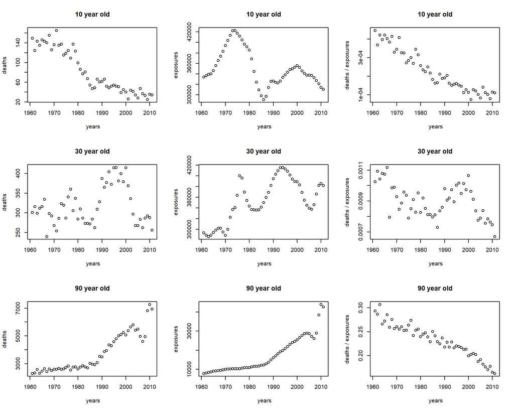

```r
# plot the number of deaths, exposures, and percentage of deaths over
# the years
par(mfrow = c(3, 3))
# 10 year olds
plot(EWMaleData$years, EWMaleData$Dxt[10, ], xlab = " years", ylab = "deaths",
    main = "10 year old")
plot(EWMaleData$years, EWMaleData$Ext[10, ], xlab = " years", ylab = "exposures",
    main = "10 year old")
plot(EWMaleData$years, EWMaleData$Dxt[10, ]/EWMaleData$Ext[10, ], xlab = " years",
    ylab = "deaths / exposures", main = "10 year old")

# 30 year olds
plot(EWMaleData$years, EWMaleData$Dxt[30, ], xlab = " years", ylab = "deaths",
    main = "30 year old")
plot(EWMaleData$years, EWMaleData$Ext[30, ], xlab = " years", ylab = "exposures",
    main = "30 year old")
plot(EWMaleData$years, EWMaleData$Dxt[30, ]/EWMaleData$Ext[30, ], xlab = " years",
    ylab = "deaths / exposures", main = "30 year old")

# 90 year olds
plot(EWMaleData$years, EWMaleData$Dxt[90, ], xlab = " years", ylab = "deaths",
    main = "90 year old")
plot(EWMaleData$years, EWMaleData$Ext[90, ], xlab = " years", ylab = "exposures",
    main = "90 year old")
plot(EWMaleData$years, EWMaleData$Dxt[90, ]/EWMaleData$Ext[90, ], xlab = " years",
    ylab = "deaths / exposures", main = "90 year old")
```

## Fitting the Lee-Carter model

Next we specify which ages and calendar years we want to fit the model to. Note that the exposures are already central, so no need to transform them.

```r
# we only look at ages between 55 and 89
ages_fit <- 55:89
# matrix with 1 if year and age is included and 0 otherwise `clip`
# indicates the number of cohorts in the boundary to assign a zero
# weight.
wxt <- genWeightMat(ages = ages_fit, years = EWMaleData$years, clip = 3)
# fit the Lee-Carter model
LC_fit <- fit(LC, data = EWMaleData, ages.fit = ages_fit, wxt = wxt)
```

```
## StMoMo: The following cohorts have been zero weigthed: 1872 1873 1874 1954 1955 1956
## StMoMo: Start fitting with gnm
## Initialising
## Running start-up iterations..
## Running main iterations......
## Done
## StMoMo: Finish fitting with gnm
```

## Analysing the model

**Parameters of the Lee-Carter model**  
Next we have a look at the fitted parameters. The package already has an implemented plotting functions which plots the parameters either against years and ages.

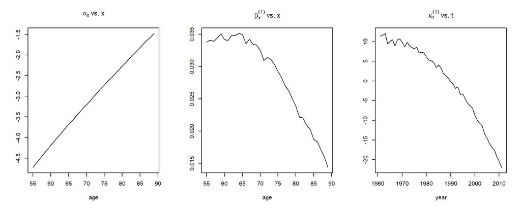

```r
# the `ncol` argument allows to put the plots next to each other.
plot(LC_fit, nCol = 3)
```

What information do these plots provide of the parameters?

**Goodness-of-fit**  
We can assess the goodness-of-fit of the model to the data by for example looking at the residuals.

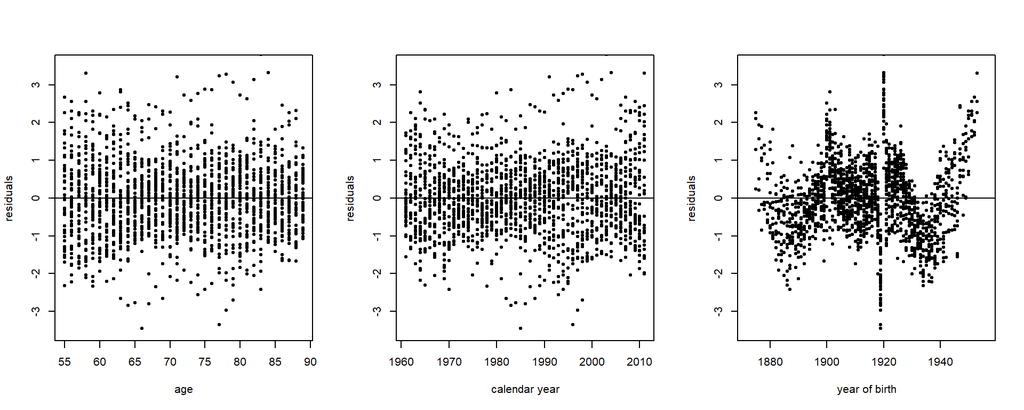

```r
LC_res <- residuals(LC_fit)
plot(LC_res, type = "scatter", reslim = c(-3.5, 3.5))
```

For model comparison, one could use for example the Bayesian Information Criterion (BIC).

## Forefasting of mortality

For forecasting, we need to know the parameter $\kappa_t$ for years that are outside our dataset. Thus, we need a time series model for modelling $\kappa_t$. One simple model is ARIMA(0,1,0), in this case a random walk with drift. For this assume that
$$\kappa_{t} = \delta + \kappa_{t-1} + \xi_t\,
\quad \text{where} \quad
\xi_t \sim N(0, \sigma^2)$$
and $\delta$ is the drift parameter. Next, from our dataset we estimate $\delta$ and $\sigma^2$ and then use them calculate $\kappa_s$ for time points $s$ outside our dataset.

Next, we use our model to forecast the number of deaths for the next 50 years.

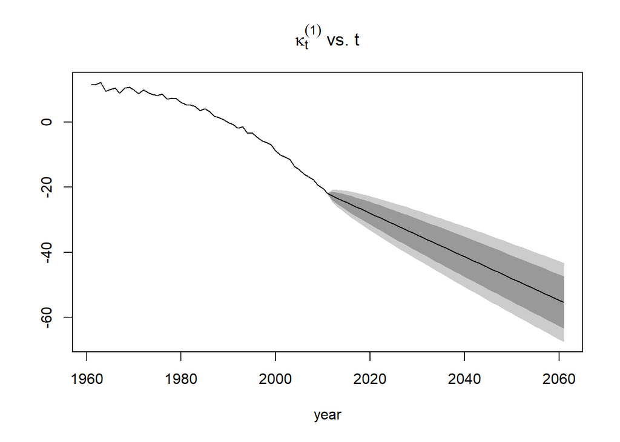

```r
# the parameter `h` are the number of years to forecast.
LC_forecast <- forecast(LC_fit, h = 50)
# plotting the parameters
plot(LC_forecast, only.kt = TRUE)
```

Next, we can simulate paths of the Lee-Carter model using `simulate` to then obtain simulated paths of the mortalities.

```r
LC_sim <- simulate(LC_fit, nsim = 500, h = 50)
```

Plotting simulations of the mortality rate for people aged 65 for the next 50 calendar years.

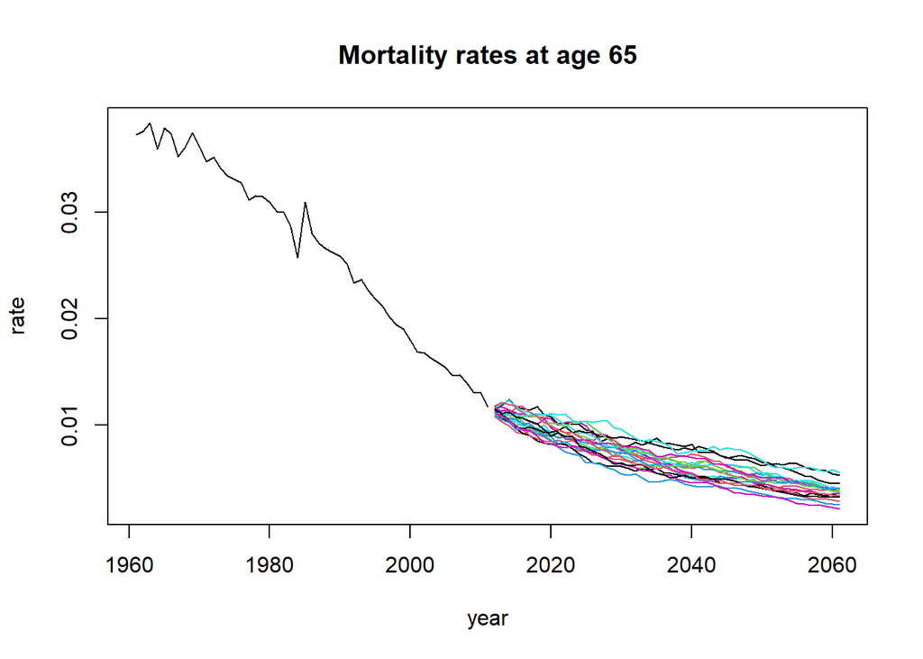

```r
qtx <- EWMaleData$Dxt/EWMaleData$Ext
plot(LC_fit$years, qtx["65", ], xlim = range(LC_fit$years, LC_sim$years),
    ylim = range(qtx["65", ], LC_sim$rates["65", , 1:20]), type = "l",
    xlab = "year", ylab = "rate", main = "Mortality rates at age 65")
matlines(LC_sim$years, LC_sim$rates["65", , 1:20], type = "l", lty = 1)
```